# Visible Built-up Index — Research & Explorer

Skip to method

VVisible Built-up Index [Launch GEE explorer ↗](https://ee-wliccust.projects.earthengine.app/view/visible-built-up-index-explorer)

REMOTE SENSING LETTERS · 2026

[figure not shown]

A built-up index designed to reveal bright urban surfaces using only red, green, and blue satellite bands—at 10-metre resolution.

[Explore any study area ↗](https://ee-wliccust.projects.earthengine.app/view/visible-built-up-index-explorer) Understand the method ↓

**0.970**VBI AUC in Córdoba

**10 m**Visible-band resolution

**615**Validation pixels

Traditional built-up indices often rely on shortwave infrared bands. VBI asks a simpler question:

## Can the brightness and color purity of a surface reveal the built environment?

01 · METHOD

## RGB becomes a built-up signal.

Sentinel-2 red, green, and blue reflectance are transformed into HSV Value and Saturation. VBI normalizes their contrast into a single index from −1 to +1.

Sentinel-2 RGB**→**HSV transform**→**VBI

VBI =*Value − Saturation**Value + Saturation*

**Value** = max(red, green, blue)**Saturation** = (Value − min RGB) / Value

INTERACTIVE FORMULA LAB

### Change the visible reflectance.

Bright, low-saturation surfaces tend toward higher VBI values. Move the channels to see how the relationship changes.

Red0.72 Green0.66 Blue0.58

Simulated surface

Value**0.720**

Saturation**0.194**

VBI**0.575**

**Mapped built-up**Córdoba threshold: VBI ≥ −0.373

02 · EVIDENCE

## Tested against built-up standards.

The study compared VBI with 11 spectral indices using 615 visually interpreted pixels from Córdoba, Argentina. The main paper reports VBI, BU, and NDBI in detail.

DIAGNOSTIC ABILITY

### Area under the TOC curve

n = 615 reference pixels

**VBI****0.970**

**BU****0.916**

**NDBI****0.808**

Higher AUC indicates stronger discrimination across all possible thresholds. These values describe the Córdoba validation dataset.

VBI**−0.373**

178 of 205 built-up samples detected

86.83%

BU**−0.14**

154 of 205 built-up samples detected

75.12%

NDBI**−0.002**

128 of 205 built-up samples detected

62.44%

03 · CÓRDOBA MAP ATLAS

## From satellite scene to classification.

Move through the original study landscape, continuous index values, and final threshold maps.

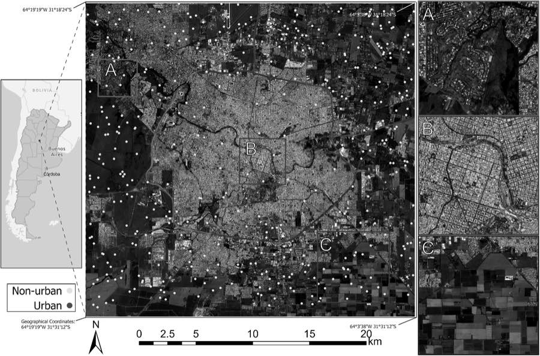

Li et al. (2026)

SENTINEL-2 · 24 JANUARY 2024

### The Córdoba study landscape

The 601 km² study area combines a dense reflective urban core, suburban vegetation, the Suquía River, cropland, and fallow fields. The points show the 615 pixels used for validation.

04 · READ BEFORE USE

## A focused index, not a universal classifier.

01

### Validate locally

The published thresholds were calibrated in Córdoba and should not be treated as globally optimal.

02

### Watch bright soils

Dry, reflective bare soil can produce a built-up-like signal and remains an important confusion class.

03

### Expect dark omissions

Terracotta roofs, asphalt roads, shadows, and vegetation-covered structures may be overlooked.

PUBLICATION

## The visible built-up index: advancing the detection of high-albedo urban areas

Weizhi Li, Aiyin Zhang & Florencia Sangermano · *Remote Sensing Letters*, 17(2), 123–131 (2026)

[Read the paper ↗](https://doi.org/10.1080/2150704X.2025.2609845)[View code & data ↗](https://github.com/vanchy-li/VBI/tree/Wins)